# Practice Code: Day 2

Author

Constantin Manuel Bosancianu

Published

July 30, 2019

# 1 Introduction

We start as yesterday, by loading a few needed packages, and by defining a few custom functions we use below.

**Warning**: the code chunk below will require that these packages are already installed on your system.

```python
import pandas as pd
pd.set_option('display.precision', 2)
import numpy as np
import pyreadr as prr
import os
import random
from plotnine import *
import statsmodels.formula.api as sm1
import statsmodels.api as sm2
import statsmodels.stats.api as sms
import scipy as sp
import matplotlib.pyplot as plt
```

```python
def regress(data, yvar, xvars):
    Y = data[yvar]
    X = data[xvars]
    X['intercept'] = 1.
    result = sm2.OLS(Y, X).fit()
    return pd.DataFrame(result.summary2().tables[1])

def fun_std_err(vec):
     np.std(vec, ddof = 1) / np.sqrt(np.size(vec))
```

# 2 Reading data

Read the same ISSP data set we used yesterday; we keep only the variables we will use today, and do listwise deletion of missing data from the outset.

```python
result = prr.read_r("../02-data/01-ISSP.rds")
df_issp = result[None]

df_issp = df_issp[["cnt", "year", "country", "poleff", "female",
                   "age10", "educ", "urban", "incquart", "ti_cpi"]]
df_issp = df_issp.dropna()

# Convert a few of the predictors into categorical indicators
for col in ["female", "urban", "incquart"]:
     df_issp[col] = df_issp[col].astype("category")
```

# 3 Complete pooling vs. no pooling

Complete pooling designates the model that we fit yesterday - it uses the entire sample to estimate the relationship between predictors and outcome, without any thought given to group membership.

```python
ols_1 = sm1.ols(formula = "poleff ~ age10 + female + educ + urban + incquart",
                data = df_issp).fit()
print(ols_1.summary())
```

```
                            OLS Regression Results
==============================================================================
Dep. Variable:                 poleff   R-squared:                       0.098
Model:                            OLS   Adj. R-squared:                  0.098
Method:                 Least Squares   F-statistic:                     585.0
Date:                Mon, 27 Feb 2023   Prob (F-statistic):               0.00
Time:                        20:51:15   Log-Likelihood:                -41913.
No. Observations:               37628   AIC:                         8.384e+04
Df Residuals:                   37620   BIC:                         8.391e+04
Df Model:                           7
Covariance Type:            nonrobust
=================================================================================
                    coef    std err          t      P>|t|      [0.025      0.975]
---------------------------------------------------------------------------------
Intercept         2.1665      0.019    111.229      0.000       2.128       2.205
female[T.1.0]    -0.1434      0.008    -18.772      0.000      -0.158      -0.128
urban[T.1.0]      0.0874      0.008     11.290      0.000       0.072       0.103
incquart[T.2]     0.0711      0.011      6.549      0.000       0.050       0.092
incquart[T.3]     0.1337      0.011     12.138      0.000       0.112       0.155
incquart[T.4]     0.2538      0.011     22.342      0.000       0.232       0.276
age10             0.0347      0.002     15.291      0.000       0.030       0.039
educ              0.0434      0.001     43.976      0.000       0.041       0.045
==============================================================================
Omnibus:                      120.103   Durbin-Watson:                   1.624
Prob(Omnibus):                  0.000   Jarque-Bera (JB):              130.474
Skew:                           0.105   Prob(JB):                     4.65e-29
Kurtosis:                       3.197   Cond. No.                         76.4
==============================================================================

Notes:
[1] Standard Errors assume that the covariance matrix of the errors is correctly specified.
```

Based on this model, all we can say is that the effect of education, or gender, on political efficacy is the same for every respondent, irrespective of which country they come from. Its virtue is that it uses information from the entire sample to estimate the relationship, which results in very small standard errors.

The alternative is what we tried yesterday: running each model separately for each group. The challenge with this approach is that the only information used in the estimation originates with the group itself.

Take as an example the case of Poland. Suppose that instead of 1,892 cases, it had 378 observations (about 20% of the original sample).[^1]

<sup>1</sup> The results here might be slightly different than in the corresponding `R` script, given the different set of rows sampled. The plot will be slightly different as well, in terms of the relative placement of Poland on the horizontal axis.

```python
df_pl = df_issp[df_issp["cnt"] == "PL"].sample(n = 378, random_state = 24057)

frames = [df_issp[df_issp["cnt"] != "PL"], df_pl]
df_issp_temp = pd.concat(frames)
```

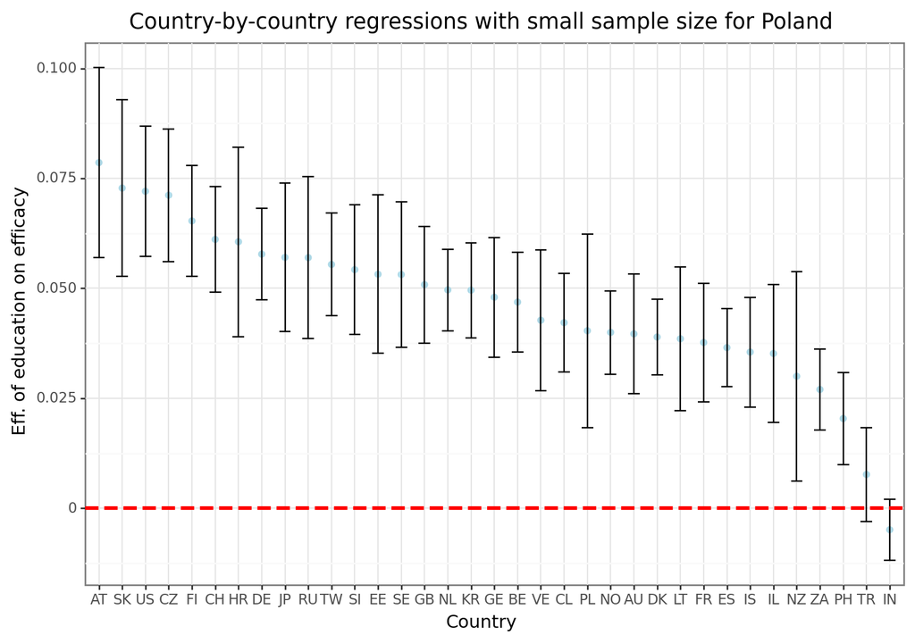

```python
df_res = df_issp_temp.groupby('cnt').apply(regress, 'poleff',
               ['age10', 'female', 'educ', 'urban', 'incquart']).reset_index()

df_res = df_res.rename({'level_1': 'level', 'Coef.': 'coef',
                        'Std.Err.': 'stderr', 't': 'tval', 'P>|t|': 'pvalue',
                        '[0.025': 'ci_lo', '0.975]': 'ci_hi'}, axis = 1)

df_res = df_res.loc[df_res['level'] == 'educ']
df_res = df_res.drop(['level', 'stderr', 'tval', 'pvalue'], axis = 1)

(
     ggplot(df_res) +
     geom_point(aes(x = "reorder(cnt, -coef)",
                    y = "coef"),
                    color = "LightBlue") +
     geom_errorbar(aes(x = "reorder(cnt, -coef)",
                       ymin = "ci_lo",
                       ymax = "ci_hi")) +
     geom_hline(yintercept = 0,
                size = 1.25,
                color = "red",
                linetype = "dashed") +
     labs(x = "Country",
          y = "Eff. of education on efficacy",
          title = "Country-by-country regressions with small sample size for Poland") +
     theme_bw() +
     theme(figure_size=(9, 6))
)
```

# 4 Multilevel model: random intercepts

We will use the `mixedlm()` function from the `statsmodels` library for these models.

## 4.1 First model

```python
mlm_1 = sm1.mixedlm("poleff ~ age10 + female + educ + urban + incquart",
                    df_issp_temp,
                    groups = df_issp_temp["cnt"]).fit(maxiter = 200000,
                                                      method = "Powell")
```

```python
print(mlm_1.summary())
```

```
          Mixed Linear Model Regression Results
=========================================================
Model:            MixedLM Dependent Variable: poleff
No. Observations: 36114   Method:             REML
No. Groups:       35      Scale:              0.4759
Min. group size:  378     Log-Likelihood:     -37953.7812
Max. group size:  2202    Converged:          Yes
Mean group size:  1031.8
---------------------------------------------------------
              Coef.  Std.Err.    z    P>|z| [0.025 0.975]
---------------------------------------------------------
Intercept      2.184    0.052  42.292 0.000  2.083  2.285
female[T.1.0] -0.120    0.007 -16.360 0.000 -0.134 -0.105
urban[T.1.0]   0.052    0.008   6.503 0.000  0.036  0.067
incquart[T.2]  0.072    0.010   6.903 0.000  0.051  0.092
incquart[T.3]  0.143    0.011  13.581 0.000  0.122  0.164
incquart[T.4]  0.271    0.011  24.824 0.000  0.249  0.292
age10          0.038    0.002  16.451 0.000  0.033  0.042
educ           0.041    0.001  38.803 0.000  0.039  0.043
Group Var      0.079    0.028
=========================================================
```

A few comments on the syntax above:

- As long as you start with the formula syntax, there’s no need to write `formula =` every time
- The model syntax is very similar to regression. on LHS of the `~` is the outcome, while on RHS of the `~` come the predictors. These would be the “fixed-effects” in the model
- The grouping factor is specified in the `groups =` argument
- As the output shows, by default the function uses REML estimation (just like in `R`). We will cover this in one of the next sessions
- Inside the `fit()` function, you can specify a few arguments that allow you to finely control the estimation process, including modifying the default tolerance value, or increasing the number of maximum iterations that the model is allowed to run for. The default for `mixedlm()` throws out a few convergence warnings. Though the warning does not affect the estimates, it is still annoying to see. This is why I used an alternative optimizer (the modified `Powell` algorithm)
- The estimates **differ** slightly from those produced by `R`, but only starting from the 3rd decimal point onward

Take a while to look a bit at the result output - looks fairly similar to that from the `ols()` function, though it shows slightly fewer details. It does, however, give you a few crucial pieces of information about the grouping structure of your data (at the top).

## 4.2 Quantities of interest

You can use a few functions to obtain the fixed effects and random effects from the model.

```python
print(mlm_1.fe_params) # The fixed effects
```

```
Intercept        2.18
female[T.1.0]   -0.12
urban[T.1.0]     0.05
incquart[T.2]    0.07
incquart[T.3]    0.14
incquart[T.4]    0.27
age10            0.04
educ             0.04
dtype: float64
```

```python
print(mlm_1.bse_fe) # SEs for the fixed effects
```

```
Intercept        5.16e-02
female[T.1.0]    7.32e-03
urban[T.1.0]     7.95e-03
incquart[T.2]    1.04e-02
incquart[T.3]    1.05e-02
incquart[T.4]    1.09e-02
age10            2.28e-03
educ             1.05e-03
dtype: float64
```

In our case, only a random intercept was specified.

```python
print(mlm_1.random_effects) # The random effects (deviations) in the model
```

```
{'AT': Group   -0.08
dtype: float64, 'AU': Group    0.18
dtype: float64, 'BE': Group   -0.07
dtype: float64, 'CH': Group    0.36
dtype: float64, 'CL': Group    0.16
dtype: float64, 'CZ': Group   -0.35
dtype: float64, 'DE': Group    0.16
dtype: float64, 'DK': Group    0.26
dtype: float64, 'EE': Group   -0.17
dtype: float64, 'ES': Group   -0.12
dtype: float64, 'FI': Group    0.03
dtype: float64, 'FR': Group    0.42
dtype: float64, 'GB': Group    0.07
dtype: float64, 'GE': Group   -0.23
dtype: float64, 'HR': Group   -0.34
dtype: float64, 'IL': Group   -0.33
dtype: float64, 'IN': Group   -0.06
dtype: float64, 'IS': Group    0.38
dtype: float64, 'JP': Group    0.11
dtype: float64, 'KR': Group   -0.29
dtype: float64, 'LT': Group   -0.44
dtype: float64, 'NL': Group    0.16
dtype: float64, 'NO': Group    0.44
dtype: float64, 'NZ': Group    0.21
dtype: float64, 'PH': Group    0.11
dtype: float64, 'PL': Group   -0.33
dtype: float64, 'RU': Group   -0.18
dtype: float64, 'SE': Group    0.24
dtype: float64, 'SI': Group   -0.55
dtype: float64, 'SK': Group   -0.35
dtype: float64, 'TR': Group    0.33
dtype: float64, 'TW': Group   -0.08
dtype: float64, 'US': Group    2.57e-03
dtype: float64, 'VE': Group    0.51
dtype: float64, 'ZA': Group   -0.18
dtype: float64}
```

You can can also get the random effect *variances* directly from the `mixedlm` object.

```python
print(mlm_1.random_effects_cov) # The variances for random effects
```

```
{'AT':           Group
Group  6.45e-04, 'AU':           Group
Group  5.82e-04, 'BE':           Group
Group  2.82e-04, 'CH':           Group
Group  4.76e-04, 'CL':           Group
Group  5.28e-04, 'CZ':           Group
Group  4.20e-04, 'DE':           Group
Group  3.21e-04, 'DK':           Group
Group  2.82e-04, 'EE':           Group
Group  9.10e-04, 'ES':           Group
Group  4.01e-04, 'FI':           Group
Group  4.93e-04, 'FR':           Group
Group  7.18e-04, 'GB':           Group
Group  3.61e-04, 'GE':           Group
Group  3.99e-04, 'HR':           Group
Group  7.24e-04, 'IL':           Group
Group  6.63e-04, 'IN':           Group
Group  4.50e-04, 'IS':           Group
Group  6.27e-04, 'JP':           Group
Group  4.02e-04, 'KR':           Group
Group  3.49e-04, 'LT':           Group
Group  6.41e-04, 'NL':           Group
Group  3.54e-04, 'NO':           Group
Group  3.88e-04, 'NZ':           Group
Group  8.47e-04, 'PH':           Group
Group  4.01e-04, 'PL':           Group
Group  1.24e-03, 'RU':           Group
Group  6.12e-04, 'SE':           Group
Group  6.09e-04, 'SI':           Group
Group  8.19e-04, 'SK':           Group
Group  4.79e-04, 'TR':           Group
Group  4.39e-04, 'TW':           Group
Group  3.58e-04, 'US':           Group
Group  4.13e-04, 'VE':           Group
Group  5.10e-04, 'ZA':           Group
Group  2.16e-04}
```

You can also ask for the confidence intervals, if you prefer them.

```python
mlm_1.conf_int(alpha = 0.05)
```

|  | 0 | 1 |
| --- | --- | --- |
| Intercept | 2.08 | 2.29 |
| female[T.1.0] | -0.13 | -0.11 |
| urban[T.1.0] | 0.04 | 0.07 |
| incquart[T.2] | 0.05 | 0.09 |
| incquart[T.3] | 0.12 | 0.16 |
| incquart[T.4] | 0.25 | 0.29 |
| age10 | 0.03 | 0.04 |
| educ | 0.04 | 0.04 |
| Group Var | 0.09 | 0.24 |

## 4.3 Comparison: no-pooling and multilevel

How do the intercepts from the no-pooling model compare to those from the multilevel one?

I use here the variant of “no-pooling” that Gelman and Hill describe: a model with country indicators. The “-1” tells **Python** to estimate values for all countries, rather than use one of the countries as reference group.

```python
df_issp_temp["cnt"] = df_issp_temp["cnt"].astype("category")

mod_np = sm1.ols(formula = "poleff ~ -1 + cnt + age10 + female + educ + urban + incquart",
                 data = df_issp_temp).fit()
np_out = pd.DataFrame(mod_np.summary2().tables[1])
np_out = np_out.drop(['Std.Err.', 't', 'P>|t|'], axis = 1)
np_out = np_out.rename({'Coef.': 'coef', '[0.025': 'ci_lo', '0.975]': 'ci_hi'},
                       axis = 1)
np_out = np_out.rename_axis("term").reset_index()
np_out = pd.DataFrame(np_out[np_out['term'].str.startswith("cnt")])
np_out['model'] = "nopool"
```

We next generate the random effects from the multilevel model.[^2]

<sup>2</sup> In the code below we have to add the value of the overall intercept, since the random effects are deviations from this overall intercept.

```python
re_list = list(mlm_1.random_effects.values())
se_list = list(mlm_1.random_effects_cov.values())
cnt_list = list(mlm_1.random_effects.keys())
vec_re = []
vec_se = []
vec_cnt = []
for i in range(len(re_list)):
     vec_re.append(re_list[:][i][0])
     vec_cnt.append(cnt_list[:][i])
     vec_se.append(se_list[:][i]['Group'][0] ** (1/2))

mlm_out = pd.DataFrame({'term': vec_cnt, 'coef': vec_re, 'se': vec_se})
# To these REs, add the value of the intercept and compute CIs
mlm_out['coef'] = mlm_out['coef'] + mlm_1.fe_params[0]
mlm_out['ci_lo'] = mlm_out['coef'] - 1.96 * mlm_out['se']
mlm_out['ci_hi'] = mlm_out['coef'] + 1.96 * mlm_out['se']
mlm_out = mlm_out.drop('se', axis = 1)
mlm_out['model'] = 'mlm'
```

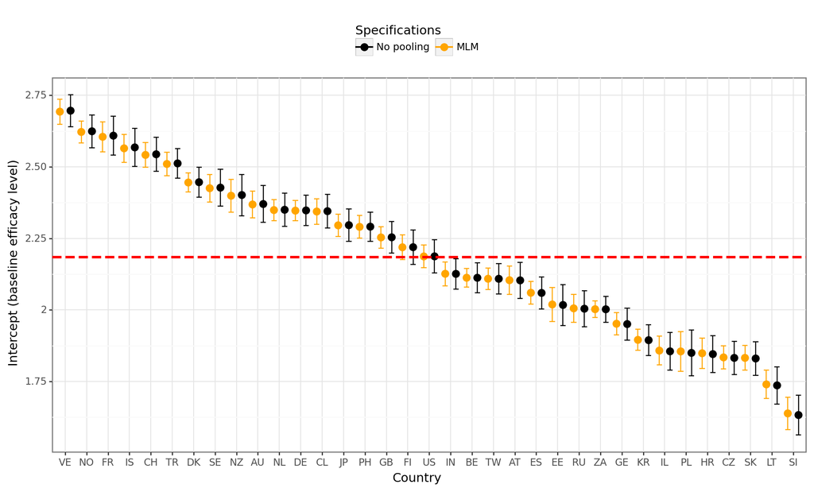

```python
frames = [np_out, mlm_out]
df_plot = pd.concat(frames)
df_plot['term'] = df_plot['term'].map(lambda x: x.lstrip('cnt[').rstrip(']'))

(
     ggplot(df_plot,
            aes(color = "model")) +
     geom_point(aes(x = "reorder(term, -coef)",
                    y = "coef"),
                size = 3,
                position = position_dodge(width = 1)) +
     geom_errorbar(aes(x = "reorder(term, -coef)",
                       ymin = "ci_lo",
                       ymax = "ci_hi"),
                   position = position_dodge(width = 1)) +
     geom_hline(yintercept = mlm_1.fe_params[0],
                size = 1.25,
                color = "red",
                linetype = "dashed") +
     labs(x = "Country",
          y = "Intercept (baseline efficacy level)") +
     scale_color_manual(name = "Specifications",
                        values = ["black", "orange"],
                        breaks = ["nopool", "mlm"],
                        labels = ["No pooling", "MLM"]) +
     theme_bw() +
     theme(figure_size = (12, 6),
           legend_position = "top")
)
```

## 4.4 ICC

We determine the need for a MLM by running a null model, and then computing the ICC.

```python
mlm_0 = sm1.mixedlm("poleff ~ 1",
                    df_issp_temp,
                    groups = df_issp_temp["cnt"]).fit(maxiter = 200000,
                                                      method = "Powell")
print(mlm_0.summary())
```

```
          Mixed Linear Model Regression Results
=========================================================
Model:            MixedLM Dependent Variable: poleff
No. Observations: 36114   Method:             REML
No. Groups:       35      Scale:              0.5231
Min. group size:  378     Log-Likelihood:     -39633.9601
Max. group size:  2202    Converged:          Yes
Mean group size:  1031.8
----------------------------------------------------------
            Coef.  Std.Err.    z     P>|z|  [0.025  0.975]
----------------------------------------------------------
Intercept   2.964     0.051  58.032  0.000   2.864   3.064
Group Var   0.091     0.031
=========================================================
```

The output already gives you all the needed information to compute the ICC.[^3]

<sup>3</sup> The residual variance is labeled in the output as `Scale`.

```python
0.091 / (0.091 + 0.5231)
```

```
0.1481843347988927
```

# 5 Add level-2 predictors

I will first re-estimate the initial model on the full data set, with the proper data for Poland (as opposed to the truncated sample).

```python
mlm_1 = sm1.mixedlm("poleff ~ age10 + female + educ + urban + incquart",
                    df_issp,
                    groups = df_issp["cnt"]).fit(maxiter = 200000,
                                                 method = "Powell")

mlm_2 = sm1.mixedlm("poleff ~ age10 + female + educ + urban + incquart + ti_cpi",
                    df_issp,
                    groups = df_issp["cnt"]).fit(maxiter = 200000,
                                                 method = "Powell")

print(mlm_2.summary())
```

```
          Mixed Linear Model Regression Results
=========================================================
Model:            MixedLM Dependent Variable: poleff
No. Observations: 37628   Method:             REML
No. Groups:       35      Scale:              0.4753
Min. group size:  517     Log-Likelihood:     -39519.5518
Max. group size:  2202    Converged:          Yes
Mean group size:  1075.1
---------------------------------------------------------
              Coef.  Std.Err.    z    P>|z| [0.025 0.975]
---------------------------------------------------------
Intercept      1.871    0.165  11.310 0.000  1.547  2.196
female[T.1.0] -0.120    0.007 -16.750 0.000 -0.134 -0.106
urban[T.1.0]   0.053    0.008   6.741 0.000  0.037  0.068
incquart[T.2]  0.072    0.010   7.123 0.000  0.052  0.092
incquart[T.3]  0.139    0.010  13.472 0.000  0.119  0.159
incquart[T.4]  0.266    0.011  24.927 0.000  0.245  0.287
age10          0.036    0.002  16.148 0.000  0.032  0.040
educ           0.041    0.001  39.251 0.000  0.039  0.043
ti_cpi         0.005    0.002   2.047 0.041  0.000  0.010
Group Var      0.072    0.026
=========================================================
```

Unfortunately, the `Stargazer()` function hasn’t been adapted for mixed-effects models, so we won’t be able to see the models with and without perceptions of corruption side-by-side.

# 6 Package versions

Package versions used in this script.

1. `ipykernel` 6.21.1
2. `ipython` 8.9.0
3. `jupyter_client` 8.0.2
4. `jupyter_core` 5.2.0
5. `matplotlib` 3.6.3
6. `matplotlib-inline` 0.1.6
7. `numpy` 1.24.2
8. `pandas` 1.5.3
9. `plotnine` 0.10.1
10. `pyreadr` 0.4.7
11. `scipy` 1.10.0
12. `stargazer` 0.0.5
13. `statsmodels` 0.13.5